# Problem Set 7

Westley Cook

4/7/2020

## Question 1: Exploratory Data Analysis

### 1A) Summary Statistics

Data summary

| Name | Piped data |
| --- | --- |
| Number of rows | 537 |
| Number of columns | 2 |
| _______________________ |  |
| Column type frequency: |  |
| numeric | 2 |
| ________________________ |  |
| Group variables | None |

**Variable type: numeric**

| skim_variable | n_missing | complete_rate | mean | sd | p0 | p25 | p50 | p75 | p100 | hist |
| --- | --- | --- | --- | --- | --- | --- | --- | --- | --- | --- |
| nominate_percentile | 0 | 1 | 49.95 | 28.95 | 0 | 24.81 | 50 | 75 | 100 | ▇▇▇▇▇ |
| age | 0 | 1 | 58.91 | 11.78 | 30 | 50.00 | 59 | 68 | 86 | ▂▅▇▇▂ |

### 1B) Visualizations

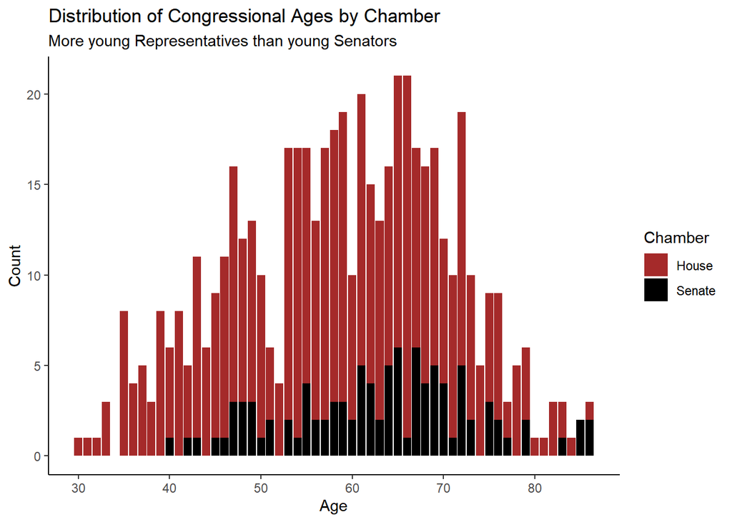

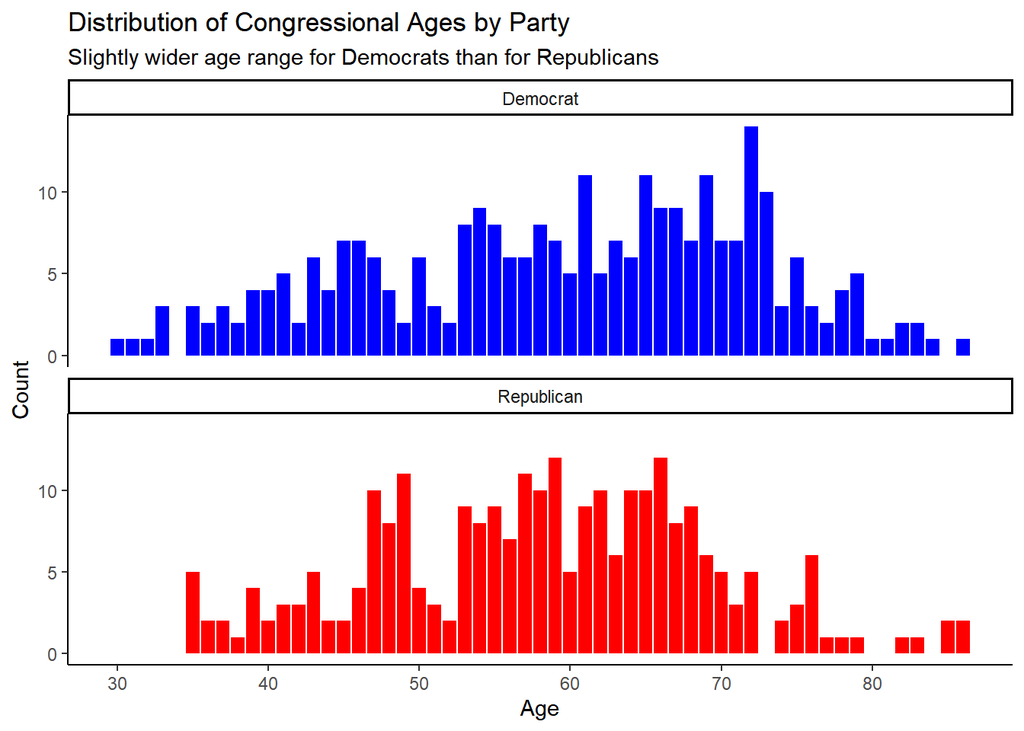

### 1C) Bivariate Correlations

The correlation coefficient for age and nominate_percentile for the 116th Congress is **-0.159**.

The negative coefficient indicates that the variables are moving in *inverse* directions: as age goes up, the percentile rank of ideology goes down. If the coefficient were positive, age and percentile rank would move in the same direction.

### 1D) Plotting Bivariate Relationships

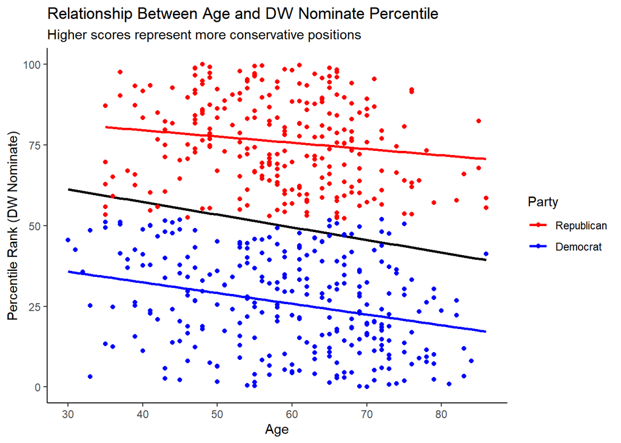

## Question 2: Single Regression

### 2A) Using lm()

Effect of Age on DW Nominate Percentile

Higher percentage suggests more conservative

| Variable | Estimate | Lower bound | Upper bound |
| --- | --- | --- | --- |
| (Intercept) | 45.7469111 | 37.4458230 | 54.0479993 |
| age | -0.3322965 | -0.4687675 | -0.1958254 |

### 2B) Interpreting results

The estimated average treatment effect is that being one year older is associated, on average, with a decrease of about one-third of a percentile (-0.33 percentile units) for a Democratic member of Congress. We should not necessarily interpret this correlation as being causal unless we’re certain that no other variables could be confounding the result. That assumption seems unlikely; for example, perhaps it’s not age itself that causes Congress members to become more liberal, but rather it’s that older members of Congress aren’t as frequently trying to be re-elected and thus don’t need to pander to the median voter by feigning extra conservatism.

We calculate a confidence interval around our average treatment effect because we don’t think that our sample of Democratic Congress members in the 116th Congress is necessarily representative of all Democratic Congress members in other sessions; calculating a confidence interval allows us to have a plausible range of values for the treatment effect (as low as -0.469 or as high as -0.196) if we want to extrapolate the correlation we found in this particular data to past or future sessions of Congress.

## Question 3: Many Regressions

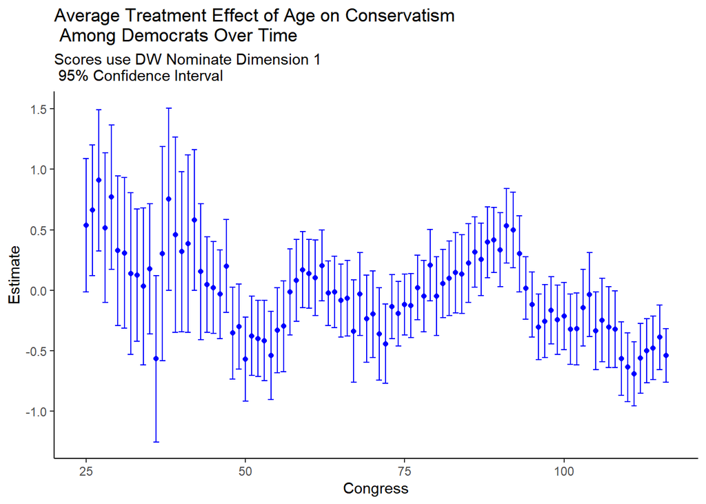

##### Worked with:

None